# pRolocGUI: Interactive visualisation of spatial proteomics data

Lisa Breckels, Thomas Naake and Laurent Gatto

# 1 Foreword

`pRolocGUI` is under active development; current functionality is evolving and new features will be added. This software is free and open-source. You are invited to contact Laurent Gatto (lg390@cam.ac.uk) or Lisa Breckels (lms79@cam.ac.uk) in case you have any questions, suggestions or have found any bugs or typos. To reach a broader audience for more general questions about proteomics analyses using R consider of writing to the Bioconductor list.

# 2 Introduction

This vignette describes the implemented functionality of the `pRolocGUI` package. The package is based on the `MSnSet` class definitions of *[MSnbase](http://bioconductor.org/packages/release/bioc/html/MSnbase.html)* and on the functions defined in the package *[pRoloc](http://bioconductor.org/packages/release/bioc/html/pRoloc.html)*. `pRolocGUI` is intended for, but not limited to, the visualisation and analysis of quantitative spatial proteomics data. To achieve reactivity and interactivity, `pRolocGUI` relies on the [`shiny`](http://www.rstudio.com/shiny/) framework.

This tutorial illustrates the usage of the `pRolocGUI` R package for the interactive visualisation of spatial proteomics data. We recommend some familiarity with the `MSnSet` class (see `?MSnSet` for details) and the `pRoloc` vignette (available with `vignette("pRoloc-tutorial")`) before using `pRolocGUI`.

There are 4 applications distributed with `pRolocGUI` which are wrapped and launched by the `pRolocVis` function. These 4 applications are called according to the argument `what` in the `pRolocVis` function which may be one of “pca”, “profiles”, “classify” and “compare”.

- The `pca` application launches a Principal Components Analysis (PCA) plot of the data and features a searchable data table to allow highlighting of specific proteins.
- The `profiles` application allows visualisation of protein profiles according to sub-cellular location which is particularly useful for discriminating between data clusters.
- The `classify` application has been designed to view machine learning classification results according to user-specified thresholds for sub-cellular localisation predictions.
- The `compare` application, allows the comparison of two comparable `MSnSet` instances, e.g. this might be of great help for analyses of changes in protein localisation in different conditions, or two different replicate experiments etc.

The `pRolocVis` function requires a minimum of two key arguments to load an application, these are `object` and `what`. The argument `object` must be of class `MSnSet` (or a list of `MSnSet` objects of length 2 for the `compare` application). The argument `what` tells the `pRolocVis` function exactly what type of application to load. One can choose from: `"pca"`, `"profiles"`, `"classify"`, `"compare"`.

The default application is PCA (`what = "pca"`). The argument `fcol` is the the feature meta-data label (`fData` column name) to be plotted. This will  
correspond to the prediction column if using `classify` application, or the markers (labelled data) otherwise (if no `fcol` is specified `markers` is used as default, with the excpetion of classify where one should specify `fcol` as the feature data column containing their classification results).

We begin by loading an example dataset from the `pRolocdata` data package.

```r
data(hyperLOPIT2015)
```

The dataset `hyperLOPIT2015` is data from using the hyperLOPIT technology on mouse E14TG2a embryonic stem cells.

`pRolocVis` needs an object of class `MSnSet` as an argument. We can launch the application with a `MSnSet` by assigning it to the argument `object`, and specifying the type of application to load using the argument `what`. For example, to load the pca application or profiles application:

```r
pRolocVis(object = hyperLOPIT2015, what = "pca")
pRolocVis(object = hyperLOPIT2015, what = "profiles")
```

Launching any of the `pRolocVis` applications will open a new tab in a separate pop-up window, and one can then open the application in your default Internet browser if desired, by clicking the ‘open in browser’ button in the top panel of the window.

To stop the applications from running press `Esc` or `Ctrl-C` in the console (or use the “STOP” button when using RStudio) and close the browser tab, where `pRolocVis` is running.

## 2.1 Which app should I use?

There are 4 different applications, each one designed to address a different specific user requirement.

- The PCA app is intended for displaying and searching your data, which features a clickable interface and zoomable PCA plot. If you would like to search for a particular protein, set of protein or protein feature this is the application to use.
- The profiles app is designed for examining the patterns of particular sets of proteins. For example, if one has several overlapping sub-cellular clusters in their data, as highlighted by PCA or otherwise, one can check for separation in all data dimensions by examining the protein profile patterns. Proteins characteristic of particular compartment have distinctive protein profile distributions.
- The classification app is designed for viewing the sub-cellular class predictions resultant from a supervised machine learning analysis (see the [pRoloc tutorial](http://bioconductor.org/packages/release/bioc/vignettes/pRoloc/inst/doc/pRoloc-tutorial.pdf) for details on spatial proteomics data analysis).
- The comparison application may be of interest if a user wishes to examine two replicate experiments, or two experiments from different conditions etc. Two PCA plots are loaded side-by-side and one can search and identify common proteins between the two data sets.

# 3 The `pca` application

To run the `pca` application using `pRolocVis`:

```r
pRolocVis(object = hyperLOPIT2015, what = "pca")
```

The `pca` application is subdivided in to two tabs: (1) PCA, and (2) profiles. A searchable data table containing the experimental feature meta-data is permanantly dispalyed at the bottom of the screen for ease. You browse between the two tabs by simply clicking on them.

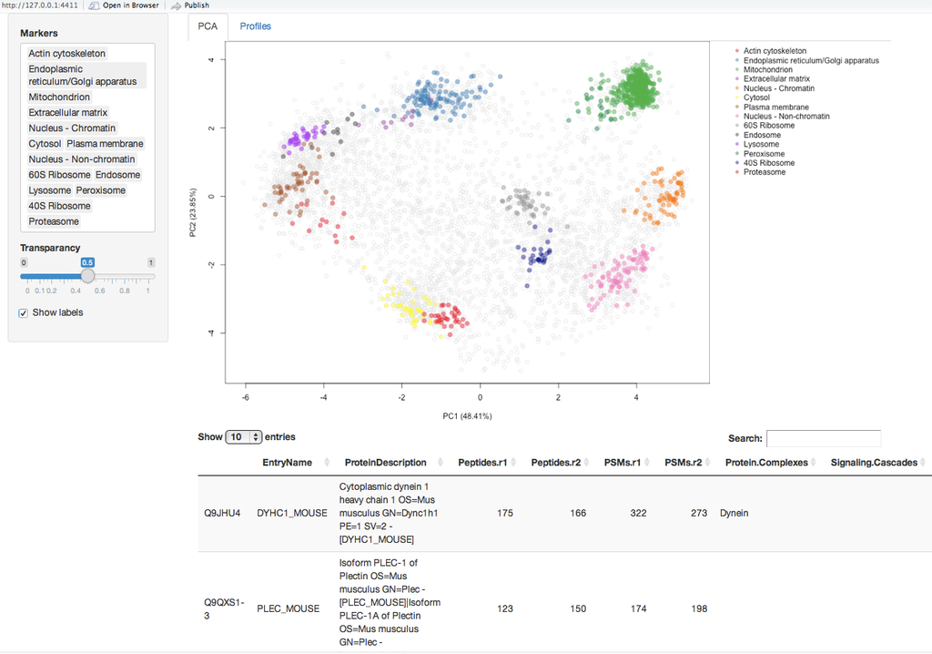

The PCA tab is characterised by its main panel which shows a PCA plot for the selected `MSnSet`. By default a PCA plot is used to display the data and the first two principal components are plotted. Given a multivariate dataset, PCA transforms the original high dimensional data into a smaller lower-dimensional set of uncorrelated variables (principal components) such that the first principal component has the largest possible variance to account for as much variability in the data as possible and each succeeding component in turn has the highest variance possible under the constraint that it be orthogonal to the preceding components. Other ordinance methods are available for displaying the data and can be specified using the `method` argument, for example, multidimensional scaling (MDS), and kernal-PCA, among other are available and are listed in `plot2Dmethods` in `pRoloc`. A matrix can also be passed to `method` where the rownames must match object’s feature names and represent a projection of the data in in two dimensions.

The sidebar panel controls what features to highlight on the PCA plot; input can be selected by clicking on and off the data classe names, or by typing and searching in the white input box. Selected items can then be deleted and the PCA plot will be updated accordingly. Below the select box is a transparancy slider bar which controls the opacity of  
the highlighted data classes. At the bottom of the sidebar panel there is a checkbox which when checked shows the protein names of any selected proteins on the PCA plot.

Below the PCA plot is a searchable data table containing the fetaure meta data (`fData`). For LOPIT experiments, such as the one used in this example, this may contain protein accession numbers, protein entry names, protein description, the number of quantified peptides per protein, and also other columns containing sub-cellular localisation information. One can search for proteins of interest by typing informationin the white search box, above the table to the right. Searching is done by partial pattern matching with table elements. Any matches or partial text matches are highlighted in yellow. To select/unselect a protein of interest one can simply click/unclick on the corresponding row in the table and the protein will be highlighted/removed on/from the PCA plot (the protein name will be displayed if the checkbox ‘labels’ is ticked.)

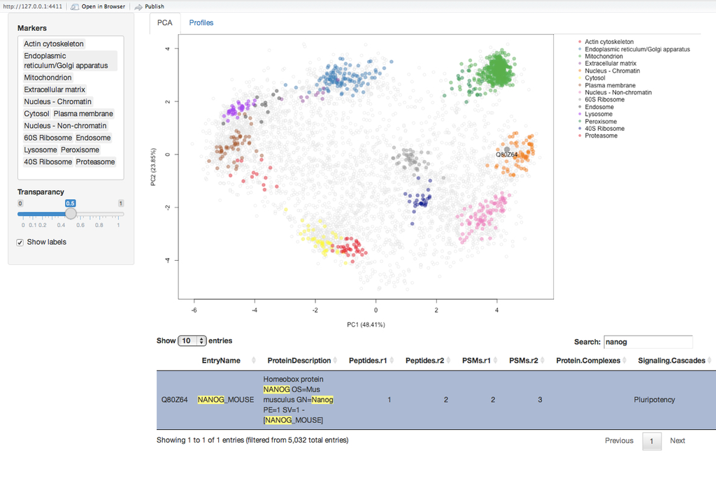

A user can switch between the PCA and profiles tab by clicking the tab at the top of the page. All protein profiles are shown in grey. For LOPIT experiments these protein profiles show the relative abundance of each protein across the fractions employed. Proteins that co-localise are expected to have similar profiles based on De Duve’s principle.

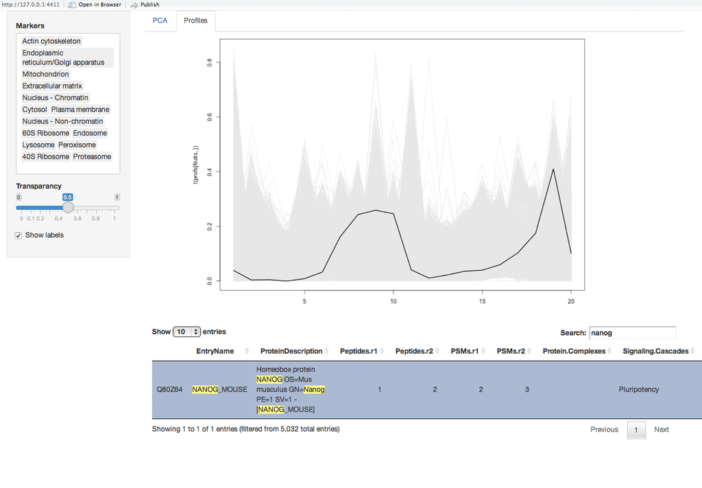

Can also use the import/export functionality by using the `FeaturesOfInterest`/`FoICollection` infrastructure distributed by the `MSnbase` package.